# Lea`R`ning Direction Effects in Retrieval Practice on EFL Vocabulary Learning

### 5.2.3 Model with Interaction

What if English proficiency only matters in one of the two learning directions? To figure this out, Terai, Yamashita & Pasich (2021) added an interaction term to the model: `s.vocab * Condition`.

```r
fit2.1 <- glmer(Answer ~ s.vocab * Condition + (1|ID) + (1|ItemID),
              family = binomial,
              data = dat.L1,
              glmerControl(optimizer = "bobyqa"))

summary(fit2.1)
```

```
Generalized linear mixed model fit by maximum likelihood (Laplace
  Approximation) [glmerMod]
 Family: binomial  ( logit )
Formula: Answer ~ s.vocab * Condition + (1 | ID) + (1 | ItemID)
   Data: dat.L1
Control: glmerControl(optimizer = "bobyqa")

      AIC       BIC    logLik -2*log(L)  df.resid
   1311.6    1341.4    -649.8    1299.6      1069

Scaled residuals:
    Min      1Q  Median      3Q     Max
-3.3577 -0.7070 -0.2723  0.7294  3.0368

Random effects:
 Groups Name        Variance Std.Dev.
 ItemID (Intercept) 0.9314   0.9651
 ID     (Intercept) 0.8583   0.9265
Number of obs: 1075, groups:  ItemID, 40; ID, 28

Fixed effects:
                   Estimate Std. Error z value Pr(>|z|)
(Intercept)        -0.04872    0.24313  -0.200  0.84117
s.vocab             0.10336    0.18596   0.556  0.57834
Condition2          0.18358    0.14125   1.300  0.19368
s.vocab:Condition2 -0.36734    0.14148  -2.596  0.00942 **
---
Signif. codes:  0 '***' 0.001 '**' 0.01 '*' 0.05 '.' 0.1 ' ' 1

Correlation of Fixed Effects:
            (Intr) s.vocb Cndtn2
s.vocab     -0.026
Condition2   0.000  0.001
s.vcb:Cndt2  0.001 -0.003  0.006
```

```r
confint(fit2.1)
```

```
Computing profile confidence intervals ...
```

```
                         2.5 %      97.5 %
.sig01              0.73079653  1.28734674
.sig02              0.67541189  1.29854303
(Intercept)        -0.53661194  0.43865902
s.vocab            -0.27346323  0.48467861
Condition2         -0.09542201  0.46370241
s.vocab:Condition2 -0.64914673 -0.08900216
```

```r
AIC(fit2.1)
```

```
[1] 1311.563
```

This model tests whether **the effect of vocabulary** differs between the learning conditions. As Terai, Yamashita & Pasich (2021) stated in their paper, the interaction of Learning Condition and Vocabulary Size is significant with a coefficient estimate of about -0.37, SE = 0.141, *z* = -2.596, *p* = .009, which means that the effect of vocabulary proficiency depends on the learning direction.

### 5.2.4 Visualization

Visualizing model predictions is a very useful way to better understand complex models like this one. Terai, Yamashita & Pasich (2021) visualized the model `fit2.1` using a base `R` plot.

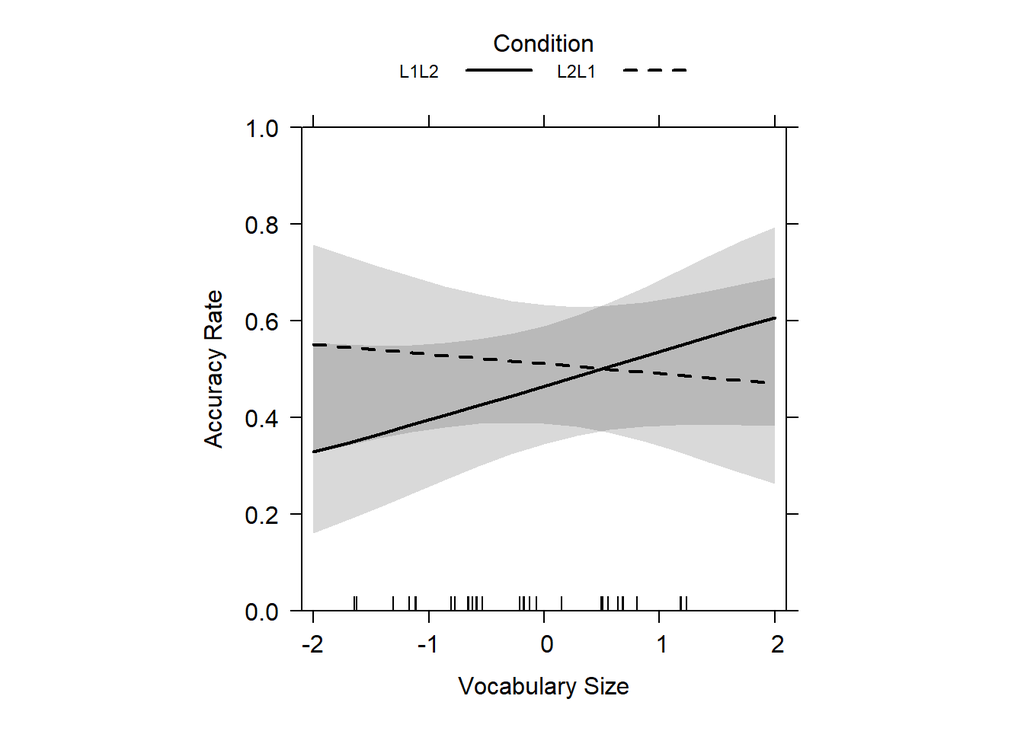

Figure 6: Predicted L1 Production accuracy across vocabulary sizes and learning directions

```r
plot(allEffects(fit2.1), multiline = T, ci.style = "bands",
    xlab = "Vocabulary Size", ylab = "Accuracy Rate",
    main = "", lty = c(1, 2),
    rescale.axis = F, ylim = c(0, 1), colors = "black", asp = 1)
```

### 5.2.5 L2 Production Test

Terai, Yamashita & Pasich (2021) repeated all the same steps for the L2 production test, now predicting accuracy for when the participants had to produce English words after learning Japanese-English pairs.

```r
# Filtering the data we need
dat.L2 <- filter(dat, Test == "L2 Production")

# Setting Condition as factors
dat.L2$Condition <- as.factor(dat.L2$Condition)

c <- contr.treatment(2)
my.coding <- matrix(rep(1/2, 2, ncol = 1))
my.simple <- c-my.coding

contrasts(dat.L2$Condition) <- my.simple

# Scaling Vocab scores
dat.L2$s.vocab <- scale(dat.L2$Vocab)
```

```r
# Model without interaction
fit3 <- glmer(Answer ~ s.vocab+Condition + (1|ID) + (1|ItemID),
              family = binomial,
              data = dat.L2,
              glmerControl(optimizer = "bobyqa"))
summary(fit3)
```

```
Generalized linear mixed model fit by maximum likelihood (Laplace
  Approximation) [glmerMod]
 Family: binomial  ( logit )
Formula: Answer ~ s.vocab + Condition + (1 | ID) + (1 | ItemID)
   Data: dat.L2
Control: glmerControl(optimizer = "bobyqa")

      AIC       BIC    logLik -2*log(L)  df.resid
   1146.5    1171.4    -568.3    1136.5      1070

Scaled residuals:
    Min      1Q  Median      3Q     Max
-2.2217 -0.5586 -0.3314  0.6289  5.0300

Random effects:
 Groups Name        Variance Std.Dev.
 ItemID (Intercept) 1.5602   1.249
 ID     (Intercept) 0.8818   0.939
Number of obs: 1075, groups:  ItemID, 40; ID, 28

Fixed effects:
            Estimate Std. Error z value Pr(>|z|)
(Intercept)  -1.1134     0.2799  -3.978 6.95e-05 ***
s.vocab       0.2293     0.1913   1.199   0.2306
Condition2   -0.2759     0.1538  -1.793   0.0729 .
---
Signif. codes:  0 '***' 0.001 '**' 0.01 '*' 0.05 '.' 0.1 ' ' 1

Correlation of Fixed Effects:
           (Intr) s.vocb
s.vocab    -0.037
Condition2  0.017 -0.001
```

```r
AIC(fit3)
```

```
[1] 1146.519
```

```r
# Model with interaction
fit3.1 <- glmer(Answer ~ s.vocab * Condition + (1|ID) + (1|ItemID),
                family = binomial,
                data = dat.L2,
                glmerControl(optimizer = "bobyqa"))
summary(fit3.1)
```

```
Generalized linear mixed model fit by maximum likelihood (Laplace
  Approximation) [glmerMod]
 Family: binomial  ( logit )
Formula: Answer ~ s.vocab * Condition + (1 | ID) + (1 | ItemID)
   Data: dat.L2
Control: glmerControl(optimizer = "bobyqa")

      AIC       BIC    logLik -2*log(L)  df.resid
   1145.3    1175.2    -566.7    1133.3      1069

Scaled residuals:
    Min      1Q  Median      3Q     Max
-2.6092 -0.5624 -0.3263  0.6291  4.8839

Random effects:
 Groups Name        Variance Std.Dev.
 ItemID (Intercept) 1.5769   1.2557
 ID     (Intercept) 0.8932   0.9451
Number of obs: 1075, groups:  ItemID, 40; ID, 28

Fixed effects:
                   Estimate Std. Error z value Pr(>|z|)
(Intercept)         -1.1196     0.2815  -3.978 6.96e-05 ***
s.vocab              0.2270     0.1925   1.179   0.2382
Condition2          -0.2623     0.1544  -1.699   0.0893 .
s.vocab:Condition2  -0.2780     0.1536  -1.809   0.0704 .
---
Signif. codes:  0 '***' 0.001 '**' 0.01 '*' 0.05 '.' 0.1 ' ' 1

Correlation of Fixed Effects:
            (Intr) s.vocb Cndtn2
s.vocab     -0.037
Condition2   0.014  0.012
s.vcb:Cndt2  0.019  0.003 -0.041
```

```r
confint(fit3.1)
```

```
Computing profile confidence intervals ...
```

```
                        2.5 %      97.5 %
.sig01              0.9458295  1.69438382
.sig02              0.6790572  1.33827015
(Intercept)        -1.6992600 -0.56667480
s.vocab            -0.1627622  0.62538807
Condition2         -0.5720030  0.04444103
s.vocab:Condition2 -0.5864708  0.02637147
```

```r
AIC(fit3.1)
```

```
[1] 1145.316
```

### 5.2.6 Visualization

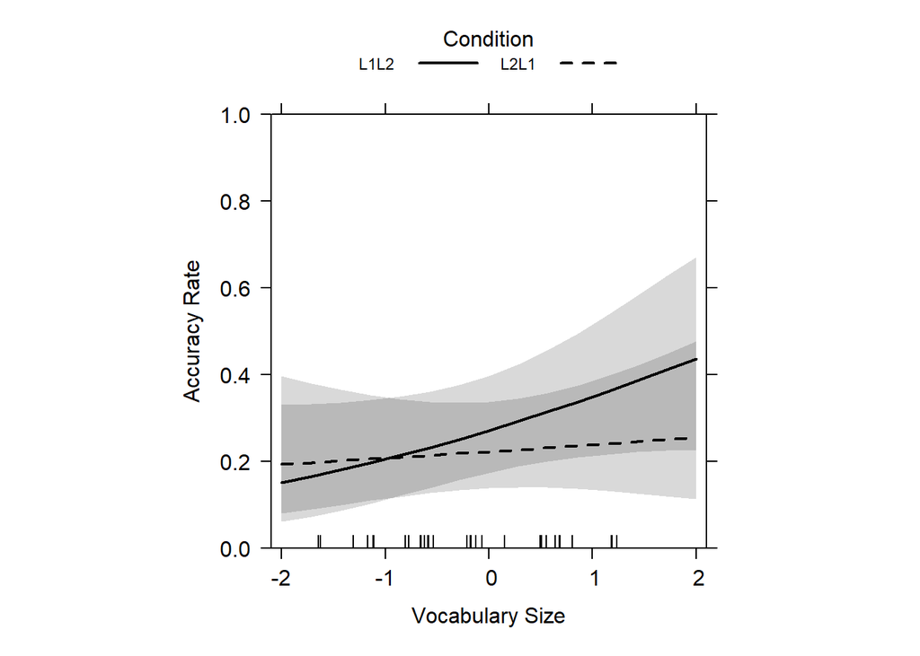

Figure 7: Predicted L2 Production accuracy across vocabulary size and learning direction

```r
plot(allEffects(fit3.1), multiline = T, ci.style = "bands", xlab = "Vocabulary Size", ylab = "Accuracy Rate",
       main = "", lty = c(1, 2), rescale.axis = F, ylim = c(0, 1), colors = "black", asp = 1)
```

Just as the summary statistics of the model above suggested, Figure 7 shows that, while there was no significance of the results for learning direction or L2 proficiency, the trend bears similartiy to the results of our L1 production test (flatter L2 -> L1 slope, steeper L1 -> L2 slope). So, for lower-proficiency learners, L2 -> L1 leads to higher performance than L1 -> L2 learning. Furthermore, the authors explained that L2 -> L1 learning is much less influenced by L2 proficiency (Terai, Yamashita & Pasich 2021: 1128), which is clearly illustrated by the nearly flat dashed line in the graphs.

### 5.2.7 Interpretation & Take-home message

Generally, for the L1 production test, Terai, Yamashita & Pasich (2021)’s results showed that lower-proficiency learners benefited more from the L2 -> L1 learning direction, while higher-proficiency learners benefited more from the L1 -> L2 learning direction. For the L2 production test, a similar trend was observed, but it was not statistically significant, which calls for replication and further research. Overall, vocabulary proficiency shapes how effectively retrieval works: the optimal learning direction is not a one-size-fits-all matter, but may rather be dependent on learner proficiency. However, it is also worth highlighting that only a single language pair was tested in this study. Assuming that the above-mentioned results are generalisable L1-L2 effects may be a bit far-fetched.

## 5.3 Checking multicollinearity

Now, before interpreting these results too confidently, one should also check whether the predictors are highly correlated with one another, which would be a problem called multicollinearity (see **?@sec-ModelAssumptions**) that might affect the results of our GLMMs.

Why does this matter? If the predictors are very strongly correlated, the model might have trouble to keep apart their unique contributions. It might then inflate standard errors and thus make estimates unreliable (Pennsylvania State University 2018).

A common diagnostic here is the Variance Inflation Factor (VIF). A VIF close to 1 means predictors are not collinear. Here are some rules: VIF = 1: perfect independence, VIF > 5: potential concern, VIF > 10: serious multicollinearity (Pennsylvania State University 2018).

### 5.3.1 Calculating VIFs for the Models

Terai, Yamashita & Pasich (2021) used a helper function `vif.mer()` to calculate VIFs for mixed models, which can be directly imported from GitHub using the `source()` function.

```r
source("https://raw.githubusercontent.com/aufrank/R-hacks/master/mer-utils.R")

vif.mer(fit1.1)
```

```
           Test2       Condition2 Test2:Condition2
        1.001121         1.004295         1.004777
```

```r
vif.mer(fit2.1)
```

```
           s.vocab         Condition2 s.vocab:Condition2
          1.000008           1.000044           1.000049
```

```r
vif.mer(fit3.1)
```

```
           s.vocab         Condition2 s.vocab:Condition2
          1.000152           1.001814           1.001678
```

All the VIF values are obviously quite close to 1. This means that the predictors (s.vocab, Condition, and their interaction) are not correlated with each other in problematic ways. We can therefore be confident that the estimates of the interaction effects that were observed in the GLMMS are not due to multicollinearity.

# 6 Conclusion

You are now familiar with the interpretation of generalized linear mixed models! You have learned how to fit them, interpret their main effects and interactions, as well as checking for multicollinearity using the VIF measure. GLMMs are powerful tools for predicting binary outcomes such as true-false accuracy measures. They allow us to account for repeated measures across participants and items such as we encountered in this study by Terai, Yamashita & Pasich (2021). It is completely normal that at times GLMMs can feel intimidating: coding contrasts and interpreting the outcomes are not always straightforward. But there is always a solution. The insights we can gain from a nicely fitted model make all this effort worthwhile.

Owing to the fact that Terai, Yamashita & Pasich (2021) published their dataset and `R` code along with the publication, we were able to reproduce their findings and gain hands-on experience with modeling. This chapter does not include the reproduction and explanation of every part of the code that the authors shared, as we focused on the analyses discussed in Terai, Yamashita & Pasich (2021). In the reproduced code, we only changed minor things, like not reloading the same dataset several times under a different name. This sort of project not only helps with our understanding of the study, but it also sharpens our skills as future SLA researchers.

**How to cite this chapter**

This is a case study chapter of the web version of the textbook “Data Analysis for the Language Sciences: A very gentle introduction to statistics and data visualisation in R” by Elen Le Foll.

Please cite the current version of this chapter as:

> Boxleitner, Hannah and Beyhan Aliy. 2025. Learning Direction Effects in Retrieval Practice on EFL Vocabulary Learning. In Elen Le Foll (Ed.), *Data Analysis for the Language Sciences: A very gentle introduction to statistics and data visualisation in R*. Open Educational Resource. https://elenlefoll.github.io/RstatsTextbook/ (accessed DATE).

## References

### Package references

[1] D. Bates, M. Mächler, B. Bolker, et al. “Fitting Linear Mixed-Effects Models Using lme4”. In: *Journal of Statistical Software* 67.1 (2015), pp. 1-48. DOI: 10.18637/jss.v067.i01.

[2] D. Bates, M. Maechler, B. Bolker, et al. *lme4: Linear Mixed-Effects Models using Eigen and S4*. R package version 1.1-37. 2025. https://github.com/lme4/lme4/.

[3] D. Bates, M. Maechler, and M. Jagan. *Matrix: Sparse and Dense Matrix Classes and Methods*. R package version 1.7-3. 2025. https://Matrix.R-forge.R-project.org.

[4] C. Boettiger. *knitcitations: Citations for Knitr Markdown Files*. R package version 1.0.12. 2021. https://github.com/cboettig/knitcitations.

[5] P. Breheny. *visreg: Visualization of Regression Models*. R package version 2.8.0. 2025. https://pbreheny.github.io/visreg/.

[6] P. Breheny and W. Burchett. “Visualization of Regression Models Using visreg”. In: *The R Journal* 9.2 (2017), pp. 56-71. DOI: 10.32614/RJ-2017-046. https://doi.org/10.32614/RJ-2017-046.

[7] G. Csárdi, J. Hester, H. Wickham, et al. *remotes: R Package Installation from Remote Repositories, Including GitHub*. R package version 2.5.0. 2024. https://remotes.r-lib.org.

[8] H. De Rosario-Martinez. *phia: Post-Hoc Interaction Analysis*. R package version 0.3-2. 2025. https://github.com/heliosdrm/phia.

[9] A. Eklund and J. Trimble. *beeswarm: The Bee Swarm Plot, an Alternative to Stripchart*. R package version 0.4.0. 2021. https://github.com/aroneklund/beeswarm.

[10] J. Fox. “Effect Displays in R for Generalised Linear Models”. In: *Journal of Statistical Software* 8.15 (2003), pp. 1-27. DOI: 10.18637/jss.v008.i15.

[11] J. Fox and J. Hong. “Effect Displays in R for Multinomial and Proportional-Odds Logit Models: Extensions to the effects Package”. In: *Journal of Statistical Software* 32.1 (2009), pp. 1-24. DOI: 10.18637/jss.v032.i01.

[12] J. Fox and S. Weisberg. *An R Companion to Applied Regression*. Third. Thousand Oaks CA: Sage, 2019. https://www.john-fox.ca/Companion/.

[13] J. Fox and S. Weisberg. *An R Companion to Applied Regression*. 3rd. Thousand Oaks CA: Sage, 2019. https://www.john-fox.ca/Companion/index.html.

[14] J. Fox and S. Weisberg. “Visualizing Fit and Lack of Fit in Complex Regression Models with Predictor Effect Plots and Partial Residuals”. In: *Journal of Statistical Software* 87.9 (2018), pp. 1-27. DOI: 10.18637/jss.v087.i09.

[15] J. Fox, S. Weisberg, and B. Price. *car: Companion to Applied Regression*. R package version 3.1-3. 2024. https://r-forge.r-project.org/projects/car/.

[16] J. Fox, S. Weisberg, and B. Price. *carData: Companion to Applied Regression Data Sets*. R package version 3.0-5. 2022. https://r-forge.r-project.org/projects/car/.

[17] J. Fox, S. Weisberg, B. Price, et al. *effects: Effect Displays for Linear, Generalized Linear, and Other Models*. R package version 4.2-4. 2025. https://cran.r-project.org/package=effects.

[18] G. Grolemund and H. Wickham. “Dates and Times Made Easy with lubridate”. In: *Journal of Statistical Software* 40.3 (2011), pp. 1-25. https://www.jstatsoft.org/v40/i03/.

[19] L. Komsta and F. Novomestky. *moments: Moments, Cumulants, Skewness, Kurtosis and Related Tests*. R package version 0.14.1. 2022. https://www.r-project.org.

[20] R. V. Lenth. *emmeans: Estimated Marginal Means, aka Least-Squares Means*. R package version 1.11.2. 2025. https://rvlenth.github.io/emmeans/.

[21] K. Müller. *here: A Simpler Way to Find Your Files*. R package version 1.0.1. 2020. https://here.r-lib.org/.

[22] K. Müller and H. Wickham. *tibble: Simple Data Frames*. R package version 3.2.1. 2023. https://tibble.tidyverse.org/.

[23] R Core Team. *R: A Language and Environment for Statistical Computing*. R Foundation for Statistical Computing. Vienna, Austria, 2025. https://www.R-project.org/.

[24] W. Revelle. *psych: Procedures for Psychological, Psychometric, and Personality Research*. R package version 2.5.6. 2025. https://personality-project.org/r/psych/.

[25] V. Spinu, G. Grolemund, and H. Wickham. *lubridate: Make Dealing with Dates a Little Easier*. R package version 1.9.4. 2024. https://lubridate.tidyverse.org.

[26] H. Wickham. *forcats: Tools for Working with Categorical Variables (Factors)*. R package version 1.0.0. 2023. https://forcats.tidyverse.org/.

[27] H. Wickham. *ggplot2: Elegant Graphics for Data Analysis*. Springer-Verlag New York, 2016. ISBN: 978-3-319-24277-4. https://ggplot2.tidyverse.org.

[28] H. Wickham. *stringr: Simple, Consistent Wrappers for Common String Operations*. R package version 1.5.1. 2023. https://stringr.tidyverse.org.

[29] H. Wickham. *tidyverse: Easily Install and Load the Tidyverse*. R package version 2.0.0. 2023. https://tidyverse.tidyverse.org.

[30] H. Wickham, M. Averick, J. Bryan, et al. “Welcome to the tidyverse”. In: *Journal of Open Source Software* 4.43 (2019), p. 1686. DOI: 10.21105/joss.01686.

[31] H. Wickham, W. Chang, L. Henry, et al. *ggplot2: Create Elegant Data Visualisations Using the Grammar of Graphics*. R package version 3.5.2. 2025. https://ggplot2.tidyverse.org.

[32] H. Wickham, R. François, L. Henry, et al. *dplyr: A Grammar of Data Manipulation*. R package version 1.1.4. 2023. https://dplyr.tidyverse.org.

[33] H. Wickham and L. Henry. *purrr: Functional Programming Tools*. R package version 1.0.4. 2025. https://purrr.tidyverse.org/.

[34] H. Wickham, J. Hester, and J. Bryan. *readr: Read Rectangular Text Data*. R package version 2.1.5. 2024. https://readr.tidyverse.org.

[35] H. Wickham, D. Vaughan, and M. Girlich. *tidyr: Tidy Messy Data*. R package version 1.3.1. 2024. https://tidyr.tidyverse.org.

[36] Y. Xie. *Dynamic Documents with R and knitr*. 2nd. ISBN 978-1498716963. Boca Raton, Florida: Chapman and Hall/CRC, 2015. https://yihui.org/knitr/.

[37] Y. Xie. “knitr: A Comprehensive Tool for Reproducible Research in R”. In: *Implementing Reproducible Computational Research*. Ed. by V. Stodden, F. Leisch and R. D. Peng. ISBN 978-1466561595. Chapman and Hall/CRC, 2014.

[38] Y. Xie. *knitr: A General-Purpose Package for Dynamic Report Generation in R*. R package version 1.50. 2025. https://yihui.org/knitr/.

[39] H. Zhu. *kableExtra: Construct Complex Table with kable and Pipe Syntax*. R package version 1.4.0. 2024. http://haozhu233.github.io/kableExtra/.

## References

Amano, S. & T. Kondo. 2000. *Nihongo-no-goitokusei hindo [lexical properties of japanese: frequency]*. Sanseido.

Barlaz, M. 2022. Contrast coding in r. https://marissabarlaz.github.io/portfolio/contrastcoding/#contrast-coding.

Chambers, John M. & Trevor J. Hastie. 1992. *Statistical models in s*. New York: Routledge.

Parajuli, Subash. 2023. *Chapter 7 skewness and kurtosis*. https://bookdown.org/subashparajuli/quant-r/skewness-and-kurtosis.html.

Pennsylvania State University. 2018. 10.7 - detecting multicollinearity using variance inflation factors | STAT 462. https://online.stat.psu.edu/stat462/node/180/.

Terai, Masato, Junko Yamashita & Kelly E. Pasich. 2021. Effects of learning direction in retrival practice on EFL vocabulary learning. *Studies in Second Language Acquisition* 43(5). 1116–1137. https://doi.org/https://doi.org/10.1017/S0272263121000346.